# Reproducibility Report for Study 1 by Sheppes et al (2011, Psychological Science)

Kate Petrova kpetrova@stanford.edu

December 03, 2021

## Introduction

### Background

How do people decide which emotion regulation strategy to use in any given situation? A series of experiments reported by Sheppes et al (2011) provides evidence that individuals’ choice of emotion regulation strategy is driven by emotional intensity. Specifically, **Study 1 shows that individuals prefer to use cognitive reappraisal when faced with low-intensity negative stimuli and distraction when faced with high-intensity negative stimuli.**

### Justification for choice of study

Past research on emotion-regulation choice has focused largely on *intra*personal emotion regulation. However, in everyday life, people often turn to others for help with their emotion regulation needs—a phenomenon that has come to be known as *inter*personal emotion regulation. As part of my work on interpersonal emotion regulation, I am interested in examining the role of emotional intensity in driving individuals’ preference for intrapersonal vs. interpersonal strategies. Replicating the finding from the original study (which was done in a laboratory setting) is a critical first step in establishing the robustness of the original finding as well as optimizing the experimental paradigm for online contexts.

### Anticipated challenges

The absence of corrective feedback during the training and practice phases presents a potential challenge for this replication attempt. Ways of addressing this challenge in the present replication attempt are described in detail in the Methods section of this report.

### Links

Project repository (on Github): https://github.com/psych251/sheppes2011

Original paper (as hosted in your repo): https://github.com/psych251/sheppes2011/blob/main/original_paper/sheppes2011.pdf

Preregistration: https://osf.io/uzw4q/

Experiment (same for pilot a, pilot b, and final replication): [<https://web.stanford.edu/~kpetrova/cgi-bin/experiment.html>](https://web.stanford.edu/~kpetrova/cgi-bin/experiment.html)

## Methods

### Power Analysis

Converting partial eta squared (reported in the original paper) to f^2 (which is required by the ‘pwr’ package that will be used for power analysis):

```r
effectsize::eta2_to_f2(.71)
```

```
## [1] 2.448276
```

Calculating denominator degrees of freedom (v) for estimation of target effect size for a generalized linear model:

```r
# 80% power
pwr.f2.test(u = 1, f2 = 2.45, sig.level = .05, power = .80)
```

```
##
##      Multiple regression power calculation
##
##               u = 1
##               v = 3.890104
##              f2 = 2.45
##       sig.level = 0.05
##           power = 0.8
```

```r
# 90% power
pwr.f2.test(u = 1, f2 = 2.45, sig.level = .05, power = .90)
```

```
##
##      Multiple regression power calculation
##
##               u = 1
##               v = 4.906146
##              f2 = 2.45
##       sig.level = 0.05
##           power = 0.9
```

```r
# 95% power
pwr.f2.test(u = 1, f2 = 2.45, sig.level = .05, power = .95)
```

```
##
##      Multiple regression power calculation
##
##               u = 1
##               v = 5.864192
##              f2 = 2.45
##       sig.level = 0.05
##           power = 0.95
```

*Note*:  
* *v = N - 1*  
* *I will parameterize the repeated measures ANOVA (that will be used to test the main hypothesis) as a generalized linear mixed model, which is why I used the “f2” option for power calculations.*

### Planned Sample

A priori power analysis revealed that a minimum sample size of N = 7 is required to detect the main effect f^2 = 2.45 at a significance level of alpha (two-sided) = .05 with at least 95% power. Because the effect size observed in the present replication attempt may be smaller than the effect size reported in the original study (see section on the differences from the original study below), and in order to ensure that the sample is sufficiently large after low quality observations are excluded, I will aim to recruit a sample of the same size as the one used in the original study (N = 20).

### Materials

Images from the International Affective Picture System (Lang et al., 2008; n = 8 in the training and practice phase; n = 30 in the experimental phase) will be presented to participants using a standard image presentation template in jsPsych. The same images that were used in the original experiment will be used in this replication (a full list of image IDs appears in the [Supplementary Materials:](https://github.com/psych251/sheppes2011/blob/main/original_paper/sheppes2020_supplement.pdf)) of the original paper.

### Procedure

The procedures outlined in the Method section of the original study will be followed with a few necessary deviations (see below).  
**1. Training phase.** Participants will be instructed to look at 4 images while implementing one of two regulatory strategies:  
Distraction: thinking about something that is emotionally neutral (2 trials; 1 low-intensity, 1 high-intensity).  
Reappraisal: thinking about an image in a way that reduces its negative meaning (2 trials; 1 low-intensity, 1 high-intensity).  
**2. Practice phase.** Participants will complete 8 practice trials: 4 trials with have pre-determined regulation strategy (one trial for each strategy at each intensity level) and 4 trials with participants freely choosing which strategy to use.  
**3. Experimental phase.** Participants will view 30 images for 500ms and choose one of two regulation strategies to implement for each image. They will then view each image for 5,000ms while implementing the chosen strategy. The same 30 images that were used in the original study by Sheppes et al (2011) will be used

### Analysis Plan

The authors of the original study compare how often participants choose reappraisal over distraction (DV: percentage of trials on which reappraisal was chosen) on low-intensity and high-intensity trials (IV: trial type). To characterize the magnitude of the effect of trial type on emotion regulation choice, the authors report the F-value, partial eta squared, and the 95% confidence interval. To facilitate direct comparison of the results reported in the original study to the results obtained as part of this replication attempt, I will fit a one-way repeated-measures ANOVA.

Processed data will have the following format:

```r
head(simulated_data)
```

```
## # A tibble: 6 × 4
## # Groups:   id [3]
##      id trial_type percent_reappraisal percent_distraction
##   <dbl> <fct>                    <dbl>               <dbl>
## 1     1 Low                       25                  75
## 2     1 High                      42.9                57.1
## 3     2 Low                       46.2                53.8
## 4     2 High                      35.3                64.7
## 5     3 Low                       47.4                52.6
## 6     3 High                      36.4                63.6
```

Key model parameters will be derived as follows:

```r
# The model is parameterized as a generalized linear mixed effects model for ease of implementation on tidy data. The solution is mathematically equivalent to a standard implementation of a repeated measures ANOVA.
model1 <- lmer(percent_reappraisal ~ trial_type + (1|id), simulated_data)
anova(model1, test= "F")
```

```
## Analysis of Variance Table
##            npar Sum Sq Mean Sq F value
## trial_type    1 14.883  14.883  0.0809
```

```r
confint(model1)
```

```
##                    2.5 %    97.5 %
## .sig01          0.000000 11.708257
## .sigma          9.980206 17.601808
## (Intercept)    42.907616 55.492979
## trial_typeHigh -7.383878  9.823842
```

```r
eta_squared(model1)
```

```
## # Effect Size for ANOVA (Type III)
##
## Parameter  | Eta2 (partial) |       95% CI
## ------------------------------------------
## trial_type |       4.24e-03 | [0.00, 1.00]
##
## - One-sided CIs: upper bound fixed at (1).
```

**Exclusion criteria.** Participants whose responses to open-ended questions during the training phase of the study indicate failure to follow the instructions will be excluded from analyses.

**Clarify key analysis of interest here** One-way repeated-measures ANOVA.

**Reproducibility criteria.** Given the potential challenges associated with implementing this experiment online, a large effect (partial eta squared > .14) of emotional intensity on emotion regulation choice in the expected direction will be sufficient to consider this replication attempt successful.

### Differences from Original Study

1. Unlike in the original study that was performed in a sample of undergraduate students, the present replication will be performed on a sample of participants recruited online via Prolific. This difference in sample composition is not expected to affect the key outcome of the study.
2. In addition, unlike the original experiment that took place in a laboratory setting, this replication will be conducted online. This difference in the experimental setting is not expected to affect the key outcome in and of itself. However, because participants will not be asked to talk through their emotion regulation out loud during the training and practice phases, and because there will be no experimenter to provide corrective feedback, it is possible that some participants may fail to apply distraction and reappraisal correctly, which could lead to a smaller effect size in this replication compared to the original study. To ensure compliance, participants will be asked to *write down* their approach to implementing the two strategies during two of the training trials. Participants whose responses indicate failure to follow the instructions will be excluded from analyses.
3. Finally, unlike in the original experiment, participants in the present study will not be videotaped to ensure that they are viewing the stimuli without diverting their gaze for the entire duration of stimulus presentation (500 ms during strategy selection and 5,000 ms during strategy implementation). No participants were excluded from the original study because they failed to attend to the stimuli, which is why the lack of videotaping is not expected to affect participant engagement in the present replication attempt.

### Methods Addendum (Post Data Collection)

#### Differences from pre-data collection methods plan

None.

## Results

### Pilot A

#### Participants.

Two non-naive participants.

#### Data preparation

Data preparation following the analysis plan.

```r
# Concatenated participant data as input
pilot_a = read_csv("pilot_a_rawdata/pilot_a.csv")
head(pilot_a)
```

```
## # A tibble: 6 × 9
##   rt    stimulus  key_press trial_type trial_index time_elapsed internal_node_id
##   <chr> <chr>     <chr>     <chr>            <dbl>        <dbl> <chr>
## 1 46774 <center>… 32        html-keyb…           0        46776 0.0-0.0
## 2 5901  <center>… 32        html-keyb…           1        52678 0.0-1.0
## 3 14364 iaps/303… 32        image-key…           2        67046 0.0-2.0-0.0
## 4 11733 iaps/111… 32        image-key…           3        78782 0.0-2.0-0.1
## 5 9632  iaps/220… 32        image-key…           4        88415 0.0-3.0-0.0
## 6 8611  iaps/101… 32        image-key…           5        97028 0.0-3.0-0.1
## # … with 2 more variables: subject <chr>, button_pressed <dbl>
```

```r
# Tidying + calculating % reappraisal in two types of trials
pilot_a_tidy <- pilot_a |>
  filter(grepl("l.jpg|l.JPG|h.jpg|h.JPG", stimulus)) |>
  filter(grepl("image-button-response", trial_type)) |>
  mutate(intensity = ifelse(grepl('l.jpg|l.JPG', stimulus), 'low', 'high')) |>
  select(!(c(stimulus, key_press, time_elapsed, internal_node_id))) |>
  mutate(reappraisal = grepl("0", button_pressed)) |>
  mutate(distraction = grepl("1", button_pressed)) |>
  group_by(subject, intensity) |>
  summarise(
            percent_reappraisal = ((sum(reappraisal)/(sum(distraction)+sum(reappraisal)))*100),
            percent_distraction = ((sum(distraction)/(sum(distraction)+sum(reappraisal)))*100))
# Tidy data ready for glm
head(pilot_a_tidy)
```

```
## # A tibble: 4 × 4
## # Groups:   subject [2]
##   subject intensity percent_reappraisal percent_distraction
##   <chr>   <chr>                   <dbl>               <dbl>
## 1 auxxy   high                     26.7                73.3
## 2 auxxy   low                     100                   0
## 3 j9ech   high                     26.7                73.3
## 4 j9ech   low                     100                   0
```

#### Confirmatory analysis

```r
model_pilot_a <- lmer(percent_reappraisal ~ intensity + (1|subject), pilot_a_tidy)
anova(model_pilot_a, test= "F")
```

```
## Analysis of Variance Table
##           npar Sum Sq Mean Sq    F value
## intensity    1 5377.8  5377.8 4.2607e+32
```

```r
#confint(model_pilot_a)
#eta_squared(model_pilot_a)
```

### Pilot B

#### Data preparation

Data preparation following the analysis plan.

```r
# Concatenated participant data as input
pilot_b = read_csv("pilot_b_rawdata/pilot_b.csv")
head(pilot_b)
```

```
## # A tibble: 6 × 10
##   rt      stimulus key_press trial_type trial_index time_elapsed internal_node_id
##   <chr>   <chr>    <chr>     <chr>            <dbl>        <dbl> <chr>
## 1 48336.4 <center… 32        html-keyb…           0        48372 0.0-0.0
## 2 13398.2 <center… 32        html-keyb…           1        61771 0.0-1.0
## 3 35253.4 <center… 32        html-keyb…           2        97027 0.0-2.0
## 4 34147.2 <NA>     <NA>      survey-te…           3       131188 0.0-3.0-0.0
## 5 40065.3 <NA>     <NA>      survey-te…           4       171260 0.0-3.0-1.0
## 6 47355.1 <center… 32        html-keyb…           5       218619 0.0-4.0
## # … with 3 more variables: subject <chr>, responses <chr>, button_pressed <dbl>
```

```r
# Tidying + calculating % reappraisal in two types of trials
pilot_b_tidy <- pilot_b |>
  filter(grepl("l.jpg|l.JPG|h.jpg|h.JPG", stimulus)) |>
  filter(grepl("image-button-response", trial_type)) |>
  mutate(intensity = ifelse(grepl('l.jpg|l.JPG', stimulus), 'low', 'high')) |>
  select(!(c(stimulus, key_press, time_elapsed, internal_node_id))) |>
  mutate(reappraisal = grepl("0", button_pressed)) |>
  mutate(distraction = grepl("1", button_pressed)) |>
  group_by(subject, intensity) |>
  summarise(
            percent_reappraisal = ((sum(reappraisal)/(sum(distraction)+sum(reappraisal)))*100),
            percent_distraction = ((sum(distraction)/(sum(distraction)+sum(reappraisal)))*100))
# Tidy data ready for glm
head(pilot_b_tidy)
```

```
## # A tibble: 4 × 4
## # Groups:   subject [2]
##   subject intensity percent_reappraisal percent_distraction
##   <chr>   <chr>                   <dbl>               <dbl>
## 1 af54p   high                     40                  60
## 2 af54p   low                      46.7                53.3
## 3 gnpzc   high                     26.7                73.3
## 4 gnpzc   low                      40                  60
```

#### Confirmatory analysis

```r
model_pilot_b <- lmer(percent_reappraisal ~ intensity + (1|subject), pilot_b_tidy)
anova(model_pilot_b, test= "F")
```

```
## Analysis of Variance Table
##           npar Sum Sq Mean Sq F value
## intensity    1    100     100       9
```

```r
confint(model_pilot_b)
```

```
##                  2.5 %    97.5 %
## .sig01        0.000000 20.863126
## .sigma        1.123045  9.267934
## (Intercept)  21.166661 45.499896
## intensitylow  1.943437 18.058149
```

```r
eta_squared(model_pilot_b)
```

```
## # Effect Size for ANOVA (Type III)
##
## Parameter | Eta2 (partial) |       95% CI
## -----------------------------------------
## intensity |           0.90 | [0.00, 1.00]
##
## - One-sided CIs: upper bound fixed at (1).
```

### Final replication results

#### Data preparation following the analysis plan.

```r
# Concatenated participant data as input
rep_data = read_csv("replication_rawdata/replication_data.csv")
head(rep_data)
```

```
## # A tibble: 6 × 10
##   rt      stimulus key_press trial_type trial_index time_elapsed internal_node_id
##   <chr>   <chr>    <chr>     <chr>            <dbl>        <dbl> <chr>
## 1 5753.1  <center… 32        html-keyb…           0         5760 0.0-0.0
## 2 16501.2 <center… 32        html-keyb…           1        22266 0.0-1.0
## 3 48768.1 <center… 32        html-keyb…           2        71036 0.0-2.0
## 4 8751.2  <center… 32        html-keyb…           3        79788 0.0-3.0
## 5 32694.7 <NA>     <NA>      survey-te…           4       112531 0.0-4.0-0.0
## 6 15926.3 <center… 32        html-keyb…           5       128463 0.0-4.0-1.0
## # … with 3 more variables: subject <chr>, responses <chr>, button_pressed <dbl>
```

```r
# Tidying + calculating % reappraisal in two types of trials
rep_data_tidy <- rep_data |>
  filter(grepl("l.jpg|l.JPG|h.jpg|h.JPG", stimulus)) |>
  filter(grepl("image-button-response", trial_type)) |>
  mutate(intensity = ifelse(grepl('l.jpg|l.JPG', stimulus), 'low', 'high')) |>
  select(!(c(stimulus, key_press, time_elapsed, internal_node_id))) |>
  mutate(reappraisal = grepl("0", button_pressed)) |>
  mutate(distraction = grepl("1", button_pressed)) |>
  group_by(subject, intensity) |>
  summarise(
            percent_reappraisal = ((sum(reappraisal)/(sum(distraction)+sum(reappraisal)))*100),
            percent_distraction = ((sum(distraction)/(sum(distraction)+sum(reappraisal)))*100))
# Tidy data ready for glm
head(rep_data_tidy)
```

```
## # A tibble: 6 × 4
## # Groups:   subject [3]
##   subject intensity percent_reappraisal percent_distraction
##   <chr>   <chr>                   <dbl>               <dbl>
## 1 2ahf1   high                     20                  80
## 2 2ahf1   low                      86.7                13.3
## 3 2feds   high                     26.7                73.3
## 4 2feds   low                      73.3                26.7
## 5 61ex0   high                     26.7                73.3
## 6 61ex0   low                      40                  60
```

```r
# Excluding participants who did not follow instructions for at least one of the two emotion regulation strategies (N = 3)
rep_data_tidy_N17 <- rep_data_tidy |>
  filter(subject != "gy0bq" & subject != "m821x" & subject != "qz80b")
```

#### Confirmatory analysis

```r
model_replication <- lmer(percent_reappraisal ~ intensity + (1|subject),  rep_data_tidy_N17)
anova(model_replication, test = "F")
```

```
## Analysis of Variance Table
##           npar Sum Sq Mean Sq F value
## intensity    1  17422   17422  158.92
```

```r
summary(model_replication)
```

```
## Linear mixed model fit by REML ['lmerMod']
## Formula: percent_reappraisal ~ intensity + (1 | subject)
##    Data: rep_data_tidy_N17
##
## REML criterion at convergence: 254
##
## Scaled residuals:
##     Min      1Q  Median      3Q     Max
## -1.9844 -0.3444  0.0164  0.4968  1.1991
##
## Random effects:
##  Groups   Name        Variance Std.Dev.
##  subject  (Intercept) 189.6    13.77
##  Residual             109.6    10.47
## Number of obs: 32, groups:  subject, 16
##
## Fixed effects:
##              Estimate Std. Error t value
## (Intercept)    28.333      4.325   6.551
## intensitylow   46.667      3.702  12.606
##
## Correlation of Fixed Effects:
##             (Intr)
## intensitylw -0.428
```

```r
confint(model_replication)
```

```
##                  2.5 %   97.5 %
## .sig01        7.587598 21.24670
## .sigma        7.430636 14.99678
## (Intercept)  19.757661 36.90901
## intensitylow 39.198016 54.13532
```

```r
eta_squared(model_replication)
```

```
## # Effect Size for ANOVA (Type III)
##
## Parameter | Eta2 (partial) |       95% CI
## -----------------------------------------
## intensity |           0.91 | [0.82, 1.00]
##
## - One-sided CIs: upper bound fixed at (1).
```

```r
library(patchwork)
# Re-arranging data for plot
rep_data_for_plot <- rep_data |>
  filter(subject != "gy0bq" & subject != "m821x" & subject != "qz80b") |>
  filter(grepl("l.jpg|l.JPG|h.jpg|h.JPG", stimulus)) |>
  filter(grepl("image-button-response", trial_type)) |>
  mutate(low_intensity = grepl('l.jpg|l.JPG', stimulus)) |>
  mutate(high_intensity = grepl('h.jpg|h.JPG', stimulus)) |>
  select(!(c(stimulus, key_press, time_elapsed, internal_node_id))) |>
  mutate(Strategy = ifelse(grepl("0", button_pressed), "reappraisal", "distraction")) |>
  group_by(subject, Strategy) |>
  summarise(
            percent_low = ((sum(low_intensity)/(sum(high_intensity)+sum(low_intensity)))*100),
            percent_high = ((sum(high_intensity)/(sum(high_intensity)+sum(low_intensity)))*100))

# Low intensiy pie chart
low_plot <- ggplot(rep_data_for_plot,
       aes(x="",
           y=percent_low,
           fill=Strategy)) +
  geom_bar(stat="identity", width=1) +
  coord_polar("y", start=0) +
  labs(title = "Low Emotional Intensity") +
  scale_color_manual(values = c("#408F8A", "#F4B43C")) +
  scale_fill_manual(values = c("#408F8A", "#F4B43C")) +
  theme_void()

# High intensity pie chart
high_plot <- ggplot(rep_data_for_plot,
       aes(x="",
           y=percent_high,
           fill=Strategy)) +
  geom_bar(stat="identity", width=1) +
  coord_polar("y", start=0) +
  labs(title = "High Emotional Intensity")  +
  scale_color_manual(values = c("#408F8A", "#F4B43C")) +
  scale_fill_manual(values = c("#408F8A", "#F4B43C")) +
  theme_void()
```

##### Original findings:

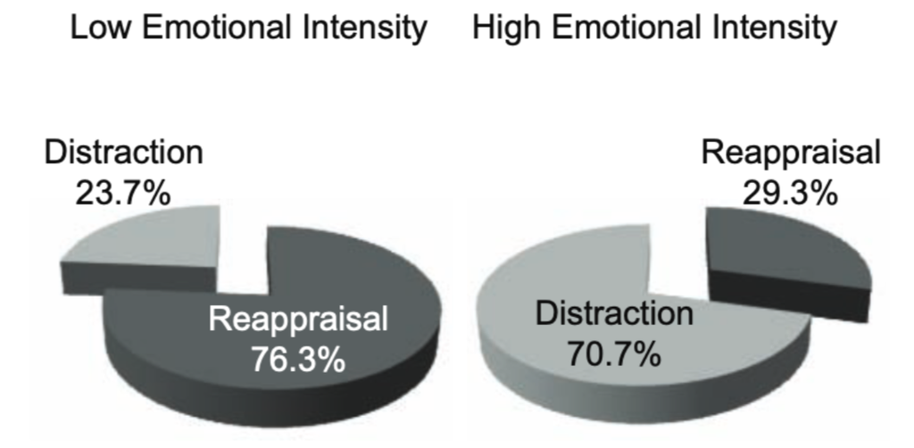

##### Replication:

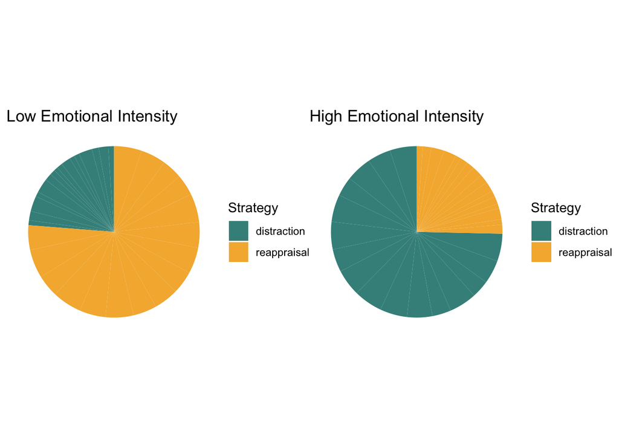

## Discussion

### Summary of Replication Attempt

The present replication study examined the effects of emotional intensity on emotion regulation choice. The results clearly indicate that individuals prefer to use reappraisal as a strategy for regulating negative emotions when emotional intensity is low and distraction when emotional intensity is high (ηp2 = .91). This is consistent with the findings by Sheppes et al (2011) who first reported this effect (ηp2 = .71).

### Commentary

Overall, the success of this replication attempt and the fact that the large effect of emotional intensity on emotion regulation choice can be detected even when participants receive no corrective feedback or supervision goes a long way in showing the robustness of the effect and further strengthening our collective confidence in what has become one of the seminal findings in contemporary affective science.

It is my hope that the fully online implementation of the emotion regulation choice paradigm that I developed for this project (and that is now publicly available in the “experiment” folder of the repository) will be a useful resource for researchers who wish to use this paradigm in future studies of emotion regulation.